# HW2 Regression Analysis

Nadezhda Lukashevich

# Введение

Врожденная катаракта – относительно редкое заболевание, которое требует оперативного вмешательства в первые месяцы жизни пациента. Поскольку зрительные функции развиваются только при стимуляции сетчатки светом, промедление грозит развитием амблиопии (“ленивого глаза”) – состояния, при котором глаз функционально здоров, но его зрение нарушено (грубо говоря, хард в порядке, а проблемы с софтом).

Существуют две стратегии лечения катаракты:

Афакия предполагает извлечение замутненного хрусталика во время первой операции. Искусственный хрусталик имплантируется во время второй операции в возрасте 6-7 лет после того, как завершены основные этапы развития глаза. Артефакия предполагает замену замутненного хрусталика на искусственный уже во время первой операции.

В обоих случаях операция проводится в первые месяцы жизни и возрастом при проведении операции можно пренебречь.

# Легенда

Вашему вниманию предлагается датасет содержащий обсервационные данные о всех пациентах одной крупной европейской больницы на протяжении двадцати лет, которые пришли на фоллоу-ап. Датасет содержит следующие переменные:

age_flwp – возраст во время фоллоу-апа в годах strat – стратегия лечения, которая была выбрана для пациента side – сторона, на которой была проведена операция glau – наличие глаукомы у пациента bcdva – острота зрения вдали, 0 – слепота, 1 – полностью сохранное зрение bcnva – острота зрения вблизи, 0 – слепота, 1 – полностью сохранное зрение

Под остротой зрения понимается острота зрения вблизи и вдали отдельно.

# Вопросы

1. Какая стратегия предпочтительна для лечения врожденной катаракты, с точки зрения остроты зрения? Не используйте информацию о наличии глаукомы при ответе на этот вопрос. 1.1. Оцените эффект стратегии без коррекции на ковариаты. 1.2. Оцените эффект стратегии с коррекцией на ковариаты. Обоснуйте необходимость включения каждой ковариаты в вашу модель.
2. Какой эффект оказывает глаукома на остроту зрения? Зависит ли этот эффект от выбранной стратегии? Опишите эффект от терапии с учетом потенциального развития глаукомы. Какая терапия предпочтительнее с учетом потенциального развития глаукомы? 2.1. Оцените эффект без коррекции на ковариаты. 2.2. Оцените эффект с коррекцией на ковариаты. Обоснуйте необходимость включения каждой ковариаты в вашу модель.
3. Как связана частота развития глаукомы с выбранной стратегией? 3.1. Оцените эффект стратегии без коррекции на ковариаты. 3.2. Оцените эффект стратегии с коррекцией на ковариаты. Обоснуйте необходимость включения каждой ковариаты в вашу модель.

# Решение

## EDA

```r
data <- read.csv("congenital_cataract.csv")
# Проверка структуры данных
str(data)
```

```
## 'data.frame':    62 obs. of  8 variables:
##  $ X       : int  1 2 3 4 5 6 7 8 9 10 ...
##  $ id      : int  778 606 229 553 722 380 754 141 615 780 ...
##  $ age_flwp: num  10.9 17 15.7 8.6 8.5 15.3 9.1 13.9 10.4 12.3 ...
##  $ strat   : chr  "Aphakia" "Artephakia" "Artephakia" "Artephakia" ...
##  $ side    : chr  "L" "L" "R" "L" ...
##  $ glau    : chr  "No" "Yes" "No" "No" ...
##  $ bcdva   : num  0.1422 0.0465 0.2355 0.4841 0.1132 ...
##  $ bcnva   : num  0.0221 0.0805 0.0266 0.0587 0.2929 ...
```

```r
print(sum(is.na(data)))
```

```
## [1] 0
```

```r
data <- data %>%
  mutate(across(where(~ !is.numeric(.)), as.factor))
summary(data)
```

```
##        X               id           age_flwp             strat    side
##  Min.   : 1.00   Min.   :133.0   Min.   : 6.200   Aphakia   :25   L:27
##  1st Qu.:16.25   1st Qu.:282.0   1st Qu.: 9.325   Artephakia:37   R:35
##  Median :31.50   Median :524.0   Median :11.450
##  Mean   :31.50   Mean   :494.4   Mean   :11.634
##  3rd Qu.:46.75   3rd Qu.:667.8   3rd Qu.:14.550
##  Max.   :62.00   Max.   :897.0   Max.   :17.000
##   glau        bcdva             bcnva
##  No :37   Min.   :0.00456   Min.   :0.01750
##  Yes:25   1st Qu.:0.03406   1st Qu.:0.09563
##           Median :0.10426   Median :0.25601
##           Mean   :0.16296   Mean   :0.32469
##           3rd Qu.:0.21347   3rd Qu.:0.50330
##           Max.   :0.80000   Max.   :0.95354
```

```r
# Пропусков нет, категории преобразовала в факторы
```

```r
library(gridExtra)
```

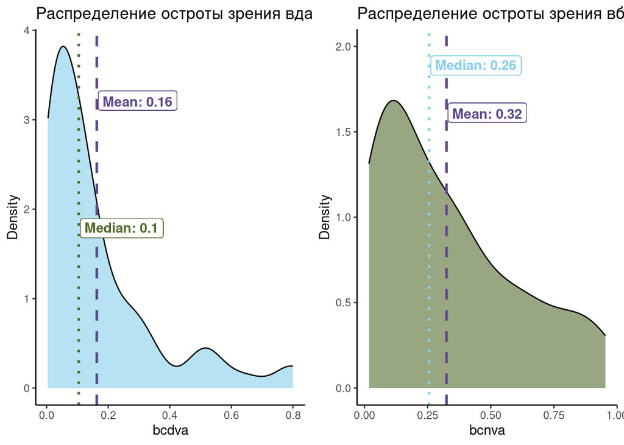

```r
density_plot <- ggplot(data, aes(x = bcdva)) +
  geom_density(fill="skyblue", alpha=0.6) +
  geom_vline(aes(xintercept = mean(bcdva)), color="mediumpurple4", linetype="dashed", size=1) +
  geom_vline(aes(xintercept = median(bcdva)), color="darkolivegreen", linetype="dotted", size=1) +
  geom_label(aes(x = mean(bcdva), label = paste("Mean:", round(mean(bcdva), 2)), y = 3), vjust = -0.5, color="mediumpurple4", hjust=-0.02, fontface = "bold") +
  geom_label(aes(x = median(bcdva), label = paste("Median:", round(median(bcdva), 2)), y = 2), vjust = 1.5, color="darkolivegreen", hjust=-0.02, fontface = "bold") +
  labs(title="Распределение остроты зрения вдали (bcdva)", x="bcdva", y="Density") +
  theme_classic()

density_plot2 <- ggplot(data, aes(x = bcnva)) +
  geom_density(fill="darkolivegreen", alpha=0.6) +
  geom_vline(aes(xintercept = mean(bcnva)), color="mediumpurple4", linetype="dashed", size=1) +
  geom_vline(aes(xintercept = median(bcnva)), color="skyblue", linetype="dotted", size=1) +
  geom_label(aes(x = mean(bcnva), label = paste("Mean:", round(mean(bcnva), 2)), y = 1.5), vjust = -0.5, color="mediumpurple4", hjust=-0.02, fontface = "bold") +
  geom_label(aes(x = median(bcnva), label = paste("Median:", round(median(bcnva), 2)), y = 2), vjust = 1.5, color="skyblue", hjust=-0.02, fontface = "bold") +
  labs(title="Распределение остроты зрения вблизи (bcnva)", x="bcnva", y="Density") +
  theme_classic()

grid.arrange(density_plot, density_plot2, ncol = 2)
```

```r
# Распределения инфильтрированны маленькими значениями, сильно несимметричны
```

```r
library(GGally)
```

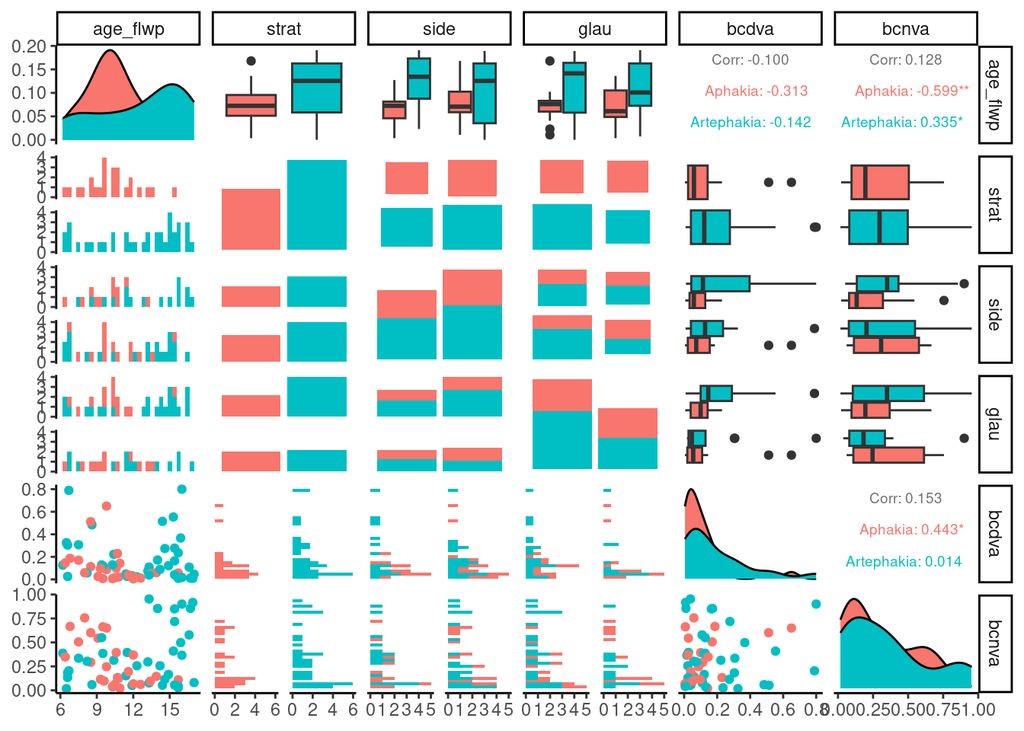

```r
g <- ggpairs(data,  mapping = aes(color = strat), upper = list(continuous = wrap("cor", size = 2.5)), columns = c('age_flwp', 'strat', 'side', 'glau', 'bcdva', 'bcnva'))+theme_classic()
g
```

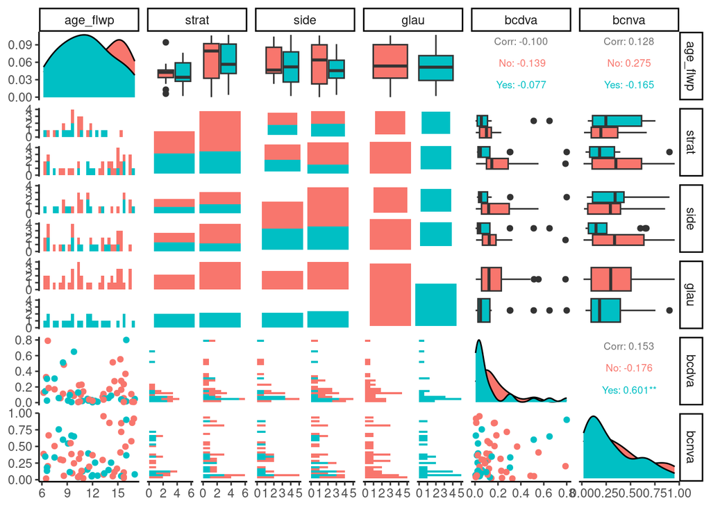

```r
g <- ggpairs(data,  mapping = aes(color = glau), upper = list(continuous = wrap("cor", size = 2.5)), columns = c('age_flwp', 'strat', 'side', 'glau', 'bcdva', 'bcnva'))+theme_classic()
g
```

### Комметарий

Здесь пока просто высказываю гипотезы. - Возраст на фоллоу ап понижен у пациентов с афакией и повышен у пациентов с артефакией, что странно, ведь у пациентов с артефакией все операции были проведены раньше, чем у пациентов с афакией. Однако, это логично, если учесть, что чем раньше во времени проводилась операция, тем больше “в моде” была артефакия. - Возраст отрицательно коррелирует в группе афакии с остротами зрения, особенно вблизи, и положительно, но слабо, в грпе артефакии для остроты вблизи, однако слабо отрицательно с остротой зрения вдали. Т.е. чем взрослее пациент на фоллоу-ап, тем слабее у него зрение вдали и особенно вблизи, если ему делали афакию; и чем взрослее пациент на фоллоу-ап, тем лучше у него зрение в вблизи, если ему делали артефакию, но при этом с возрастом не сильно меняется, а скорее понижается зрение вдали у пациентов с данной операцией. Также нужно понимать, что в группе артефакии возраст фоллоу-ап просто выше, однако по описанию задачи, видимо, повышение зрения с возрастом скорее не ожидается, если послеоперационный период пройден. - Видим положительную умеренную корреляцию острот зрения у пациентов с афакией: т.е., если у пациента высокая острота в близи, есть тенденция, что у него же высокая острота вдали. Этого не наблюдается, если пациенту делали артефакию. - Среди пациентов без глаукомы (которых больше), видимо, больше пациентов с артефакией, т.е. предположительно данная операция может понизить риск развития глаукомы. Это скорее всего не эффект возраста, поскольку в группах без и с глаукомой при артефакии распределение возраста визуально не отличается, то же в принципе можно сказать и про афакию. - Очевидное наблюдение, что острота зрения вдали в группе без глаукомы выше, однако она значительно выше для пациентов с артефакией. Для зрения вблизи тенденция сохраняется, но в группе с глаукомой контр-интутивно у пациентов с афакией достаточно высокая острота. - Пока не очень прослежию эффект стороны, однако распределение однозначно отличается среди групп с разным вмешательством. Вижу также похожие эффекты, как при глаукоме, для стороны в отношениях с остротами зрения, но трудно пока что их гипотетически объяснить.

## 1. Какая стратегия предпочтительна для лечения врожденной катаракты, с точки зрения остроты зрения? Не используйте информацию о наличии глаукомы при ответе на этот вопрос.

```r
library(car)
df <- data %>% select(-glau, -X, -id)
```

### 1.1. Оцените эффект стратегии без коррекции на ковариаты.

```r
library(rstatix)
```

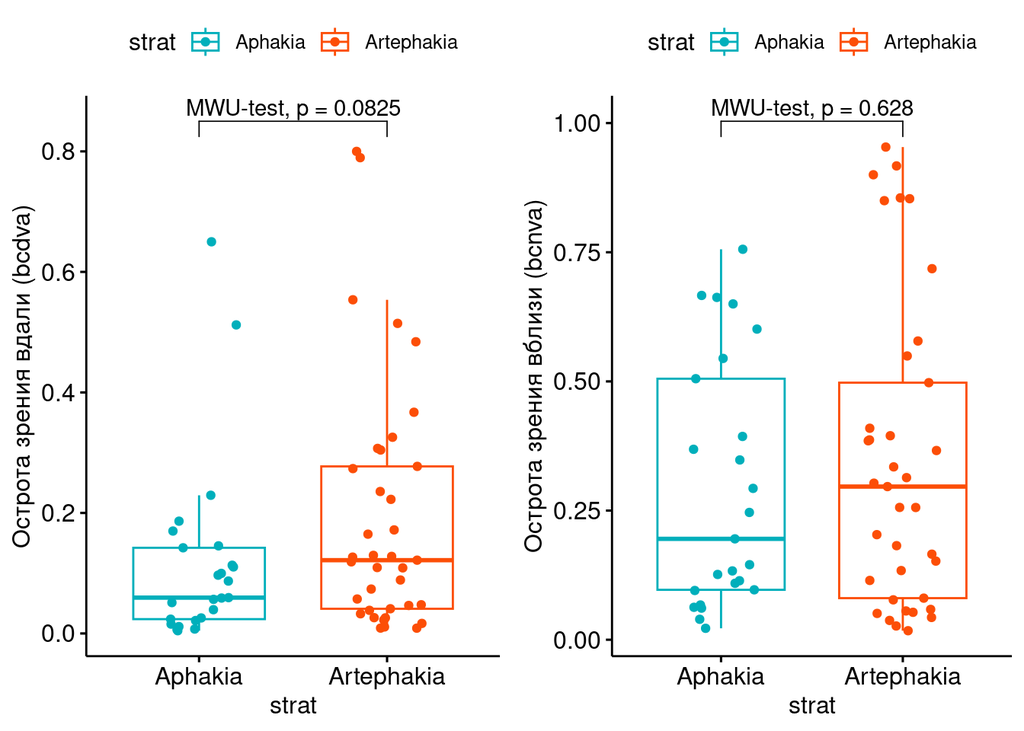

```r
library(ggpubr)

p_bcdva <- ggboxplot(df, x = "strat", y = "bcdva", color='strat', palette =c("#00AFBB", "#FC4E07"), ylab = 'Острота зрения вдали (bcdva)',  add = "jitter"
)+stat_pvalue_manual(df %>%
  wilcox_test(bcdva ~ strat, paired = FALSE), label = "MWU-test, p = {p}",
                      y.position = max(data$bcdva)+0.05)
p_bcnva <- ggboxplot(df, x = "strat", y = "bcnva",color='strat', palette =c("#00AFBB", "#FC4E07"), ylab = 'Острота зрения вблизи (bcnva)',  add = "jitter"
)+stat_pvalue_manual(df %>%
  wilcox_test(bcnva ~ strat, paired = FALSE), label = "MWU-test, p = {p}",
                      y.position = max(data$bcnva)+0.05)
grid.arrange(p_bcdva, p_bcnva, ncol = 2)
```

#### Комментарий Видим, что мощности мало, но на уровне значимости 0.1 у пациентов с артефакией острота зрения вдали выше. Острота зрения вблизи не отичается

### 1.2. Оцените эффект стратегии с коррекцией на ковариаты. Обоснуйте необходимость включения каждой ковариаты в вашу модель.

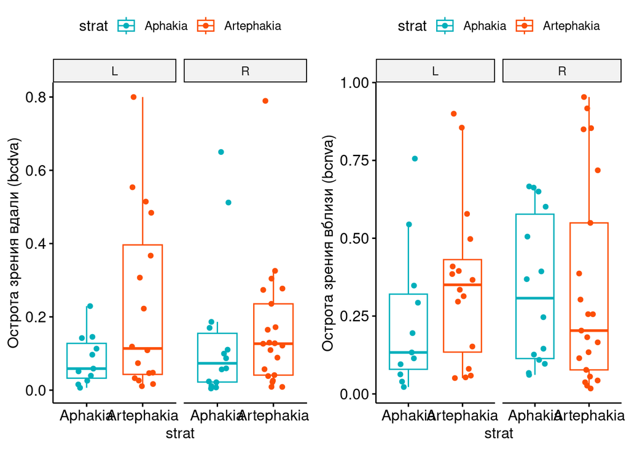

```r
# Еще раз поближе посмотрим на сторону, т.к. неуверена, что ее нужно включать
p_bcdva <- ggboxplot(df, x = "strat", y = "bcdva", color='strat', palette =c("#00AFBB", "#FC4E07"), ylab = 'Острота зрения вдали (bcdva)',  add = "jitter"
)+facet_wrap(~ side, scales = "fixed")
p_bcnva <- ggboxplot(df, x = "strat", y = "bcnva",color='strat', palette =c("#00AFBB", "#FC4E07"), ylab = 'Острота зрения вблизи (bcnva)',  add = "jitter"
)+facet_wrap(~ side, scales = "fixed")
grid.arrange(p_bcdva, p_bcnva, ncol = 2)
```

```r
# Как мне кажется, влияние стороны не очень существенное для bcnva, хотя для bcdva группа Артефакии с пораженным левым глазом как будто имеет более острое зрение
```

```r
model_bcnva <- lm(bcnva ~ strat + bcdva + age_flwp, data = df)
# Включаю: стратегию лечения как изучаемую; bcdva поскольку у пациентов с афакией остроты зрения связаны и думаю, полезно было бы выравняться на этот признак для лучшего сравнения; и на возраста на фоллоу-апе, поскольку возраст связан с остротой зрения по разному в группах вмешательства, а также возраст и вмешательство связаны между собой.
print(vif(model_bcnva))
```

```
##    strat    bcdva age_flwp
## 1.203940 1.077393 1.167070
```

```r
model_bcdva <- lm(bcdva ~ strat + bcnva + age_flwp + side, data = df)
print(vif(model_bcdva))
```

```
##    strat    bcnva age_flwp     side
## 1.133533 1.023846 1.147259 1.008897
```

```r
#Для bcdva включаю те же признаки по тем же причинам, хотя возраст связан меньше, но все же слабая связь есть. А также сторону, поскольку есть видимая связь левостороннего поражения и остроты зрения при артефакии.
#  Как и ожидалось, мультиколлинеарности в принзнаках нет
```

```r
library(lmtest)
```

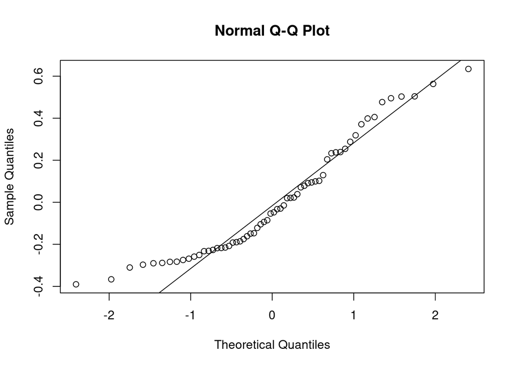

```r
qqnorm(residuals(model_bcnva))
qqline(residuals(model_bcnva))
```

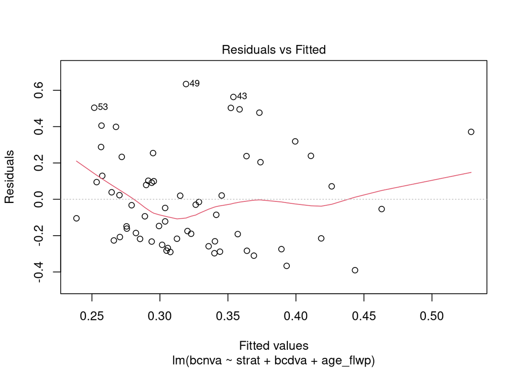

```r
plot(model_bcnva, which = 1)
```

```r
print(bptest(model_bcnva))
```

```
##
##  studentized Breusch-Pagan test
##
## data:  model_bcnva
## BP = 5.0875, df = 3, p-value = 0.1655
```

```r
print(shapiro.test(residuals(model_bcnva)))
```

```
##
##  Shapiro-Wilk normality test
##
## data:  residuals(model_bcnva)
## W = 0.92494, p-value = 0.0009893
```

```r
# Тест на гомоскедастичность подтверждает, что дисперсия остатков однородна. Тест на нормальность указывает на отклонение от нормальности распределения остатков, видимо из-за сдвига вначале. Давайте сделаем преобразование bcnva, чтобы сделать распределение более нормальным и возможно это улучшит диагностику. К сожалению, и логарифм, и логит, и бокс-кокс преобразования нормализуют распределение, но переносят его в отрицательную область, а преобразование Йео-Джонсона у меня не получилось сделать. Попробуем преобразовать и не добавлять константу, чтобы не сильно искажать интерпретируемость
```

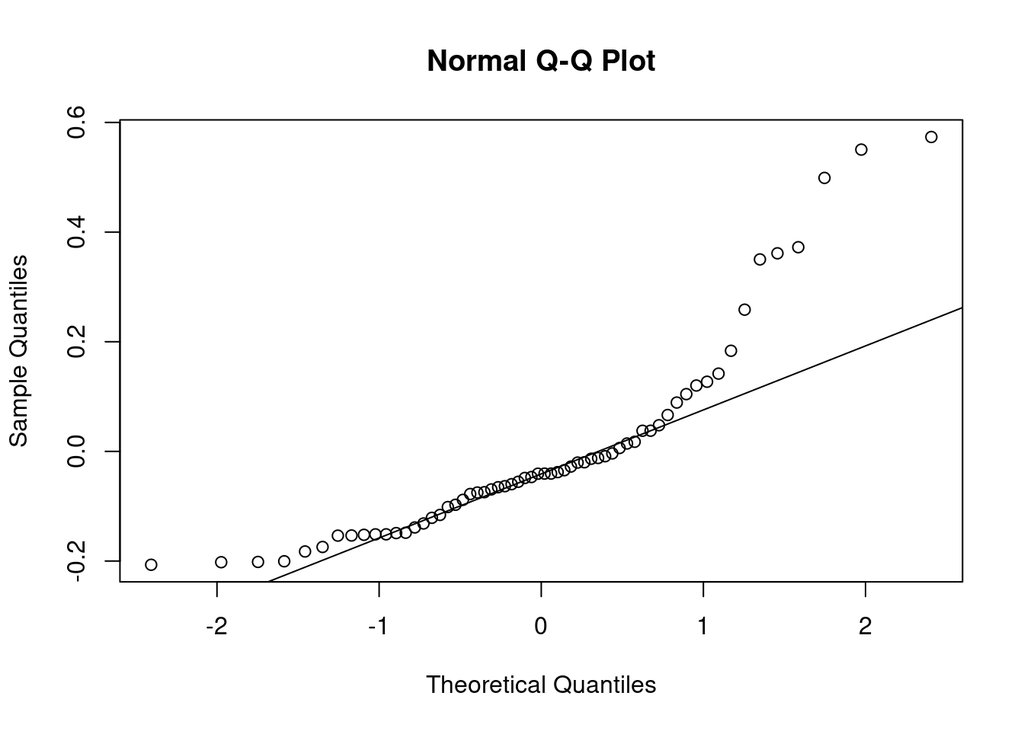

```r
qqnorm(residuals(model_bcdva))
qqline(residuals(model_bcdva))
```

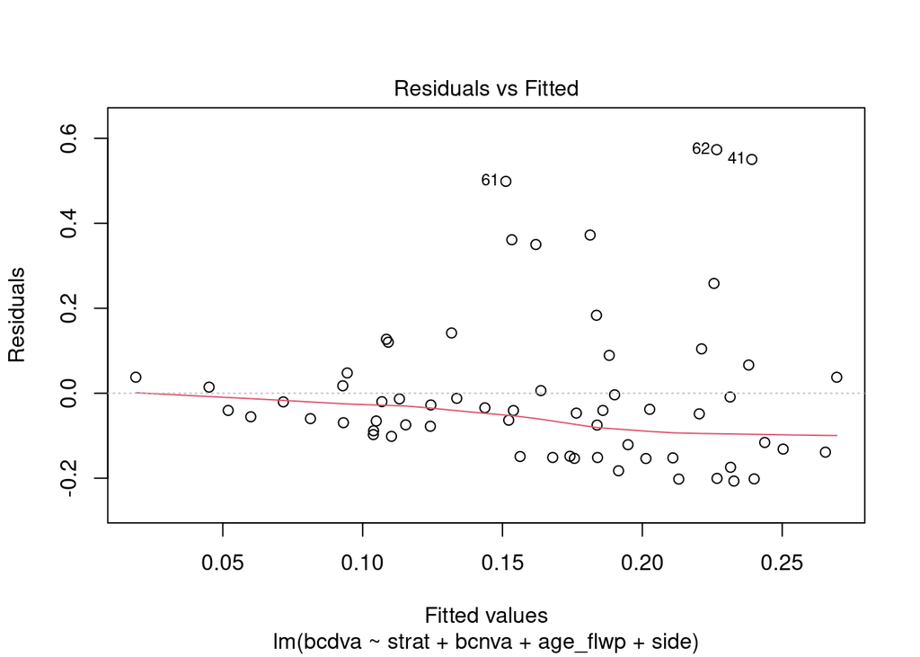

```r
plot(model_bcdva, which = 1)
```

```r
print(bptest(model_bcdva))
```

```
##
##  studentized Breusch-Pagan test
##
## data:  model_bcdva
## BP = 5.8204, df = 4, p-value = 0.213
```

```r
print(shapiro.test(residuals(model_bcdva)))
```

```
##
##  Shapiro-Wilk normality test
##
## data:  residuals(model_bcdva)
## W = 0.8273, p-value = 4.97e-07
```

```r
# Похожим образом себя ведет bcdva, преобразуем и его
```

#### Преобразование

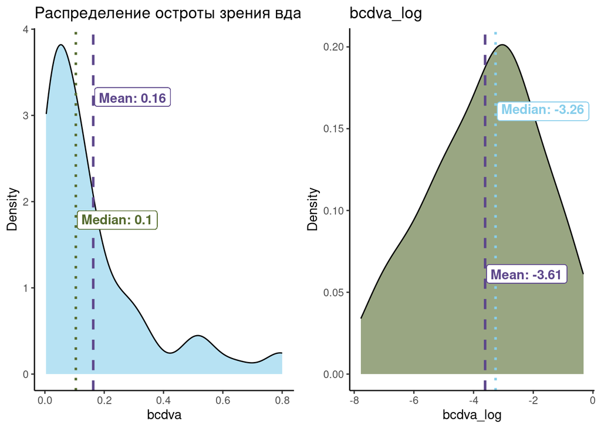

```r
df$bcdva_log <- log2(df$bcdva)

density_plot <- ggplot(df, aes(x = bcdva)) +
  geom_density(fill="skyblue", alpha=0.6) +
  geom_vline(aes(xintercept = mean(bcdva)), color="mediumpurple4", linetype="dashed", size=1) +
  geom_vline(aes(xintercept = median(bcdva)), color="darkolivegreen", linetype="dotted", size=1) +
  geom_label(aes(x = mean(bcdva), label = paste("Mean:", round(mean(bcdva), 2)), y = 3), vjust = -0.5, color="mediumpurple4", hjust=-0.02, fontface = "bold") +
  geom_label(aes(x = median(bcdva), label = paste("Median:", round(median(bcdva), 2)), y = 2), vjust = 1.5, color="darkolivegreen", hjust=-0.02, fontface = "bold") +
  labs(title="Распределение остроты зрения вдали (bcdva)", x="bcdva", y="Density") +
  theme_classic()

density_plot2 <- ggplot(df, aes(x = bcdva_log)) +
  geom_density(fill="darkolivegreen", alpha=0.6) +
  geom_vline(aes(xintercept = mean(bcdva_log)), color="mediumpurple4", linetype="dashed", size=1) +
  geom_vline(aes(xintercept = median(bcdva_log)), color="skyblue", linetype="dotted", size=1) +
  geom_label(aes(x = mean(bcdva_log), label = paste("Mean:", round(mean(bcdva_log), 2)), y = 0.05), vjust = -0.5, color="mediumpurple4", hjust=-0.02, fontface = "bold") +
  geom_label(aes(x = median(bcdva_log), label = paste("Median:", round(median(bcdva_log), 2)), y = 0.2), vjust = 4, color="skyblue", hjust=-0.02, fontface = "bold") +
  labs(title="bcdva_log", x="bcdva_log", y="Density") +
  theme_classic()

grid.arrange(density_plot, density_plot2, ncol = 2)
```

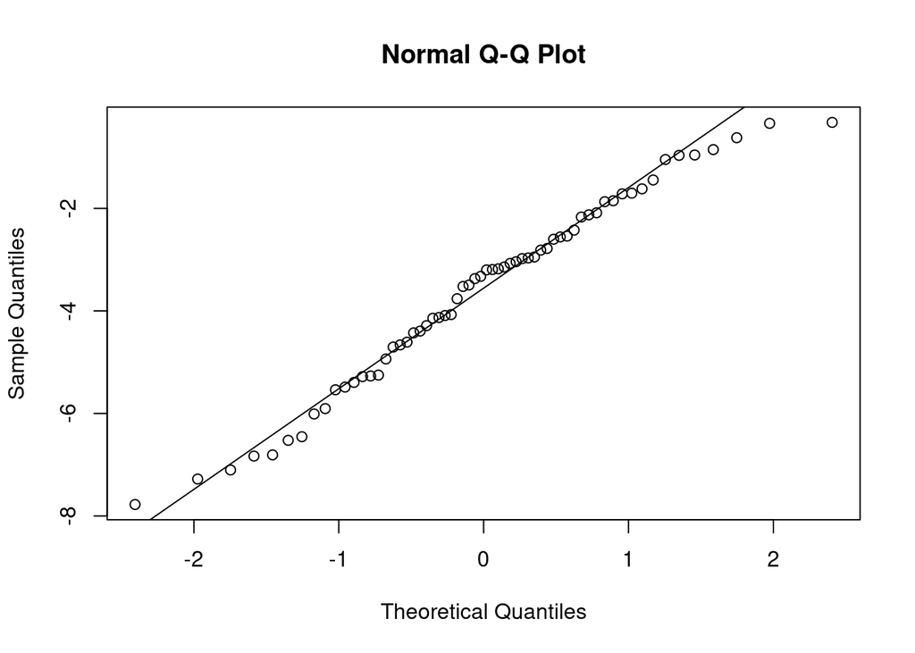

```r
qqnorm(df$bcdva_log)
qqline(df$bcdva_log)
```

```r
shapiro.test(df$bcdva_log)
```

```
##
##  Shapiro-Wilk normality test
##
## data:  df$bcdva_log
## W = 0.97651, p-value = 0.2795
```

```r
# Шалость удалась для bcdva
```